# Advanced Biological Statistics Week 4b

10/18/2018

##Linear Models and Regression

## Parent offspring regression

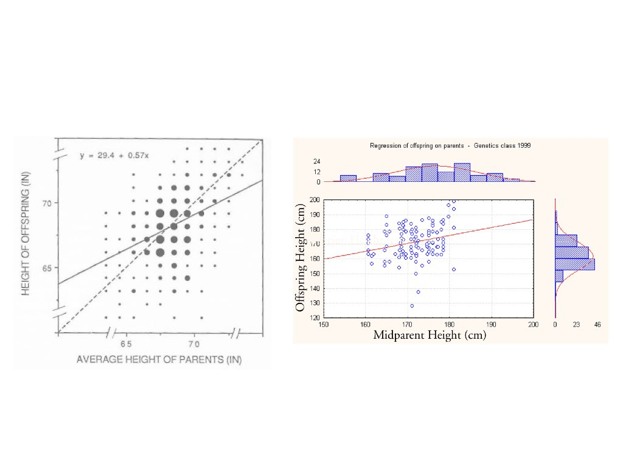

## Linear Models - a note on history

[figure not shown]

## Linear Models - a note on history

[figure not shown]

## Bivariate normality

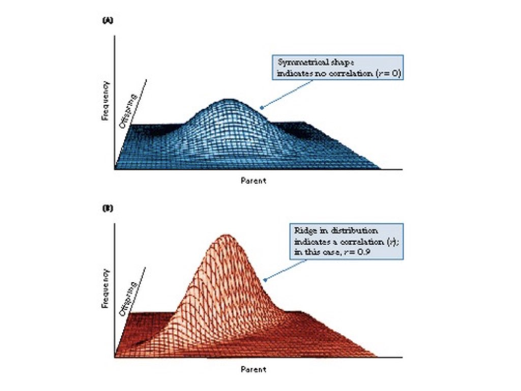

## Covariance and correlation

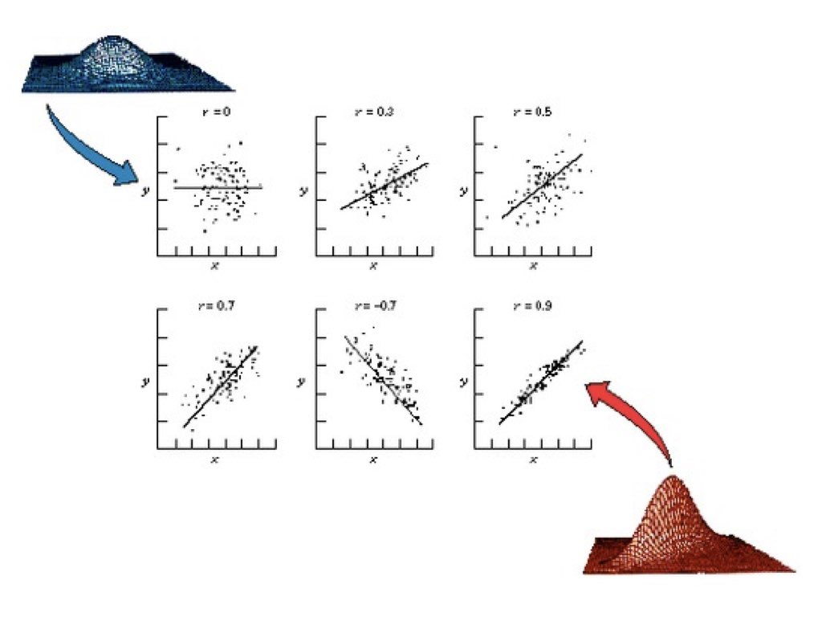

## Anscombe’s Quartet

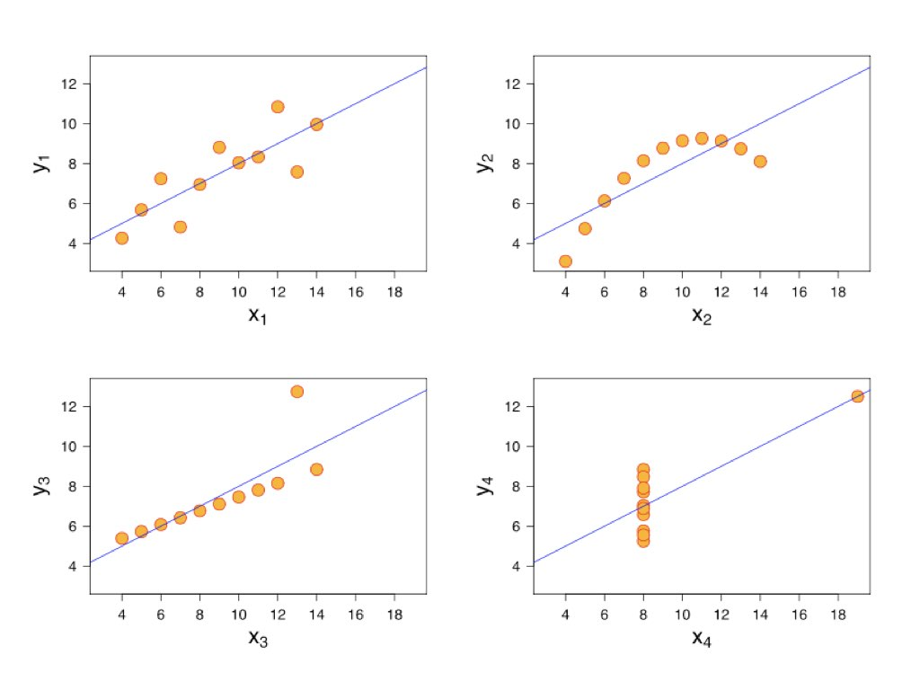

## Anscombe’s Quartet

- *Mean* of x in each case 9 (exact)
- *Variance* of x in each case 11 (exact)
- Mean of y in each case 7.50 (to 2 decimal places)
- Variance of y in each case 4.122 or 4.127 (to 3 decimal places)
- Correlation between x and y in each case 0.816 (to 3 decimal places)
- Linear regression line in each case \[ y = 3.00 + 0.50x\]

## A linear model to relate two variables

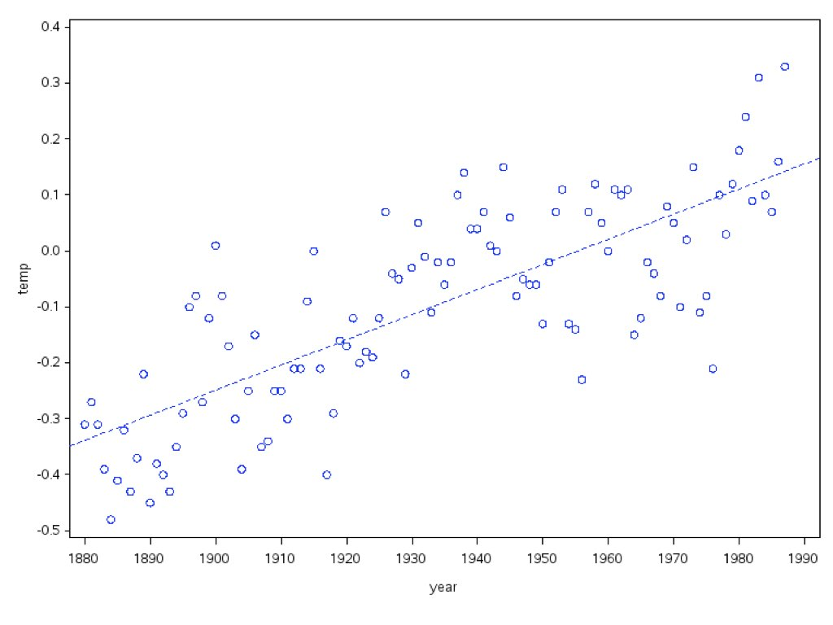

## Many approaches are linear models

- Is flexible: Applicable to many different study designs
- Provides a common set of tools (lm in R for fixed effects)
- Includes tools to estimate parameters:
  - (e.g. sizes of effects, like the slope, or change in means)
- Is easier to work with, especially with multiple variables

## Many approaches are linear models

- Linear regression
- Single factor ANOVA
- Analysis of covariance
- Multiple regression
- Multi-factor ANOVA
- Repeated-measures ANOVA

## Plethora of linear models

- General Linear Model (**GLM**) - two or more continuous variables
- General Linear Mixed Model (**GLMM**) - a continuous response variable with a mix of continuous and categorical predictor variables
- Generalized Linear Model - a GLMM that doesn’t assume normality of the response (we’ll get to this later)
- Generalized Additive Model (**GAM**) - a model that doesn’t assume linearity (we won’t get to this later)

## Linear models

All an be written in the form

response variable = intercept + (explanatory_variables) + random_error

in the general form:

\[ Y=\beta_0 +\beta_1*X_1 + \beta_2*X_2 +... + error\]

where \(\beta_0, \beta_1, \beta_2, ....\) are the parameters of the linear model

## linear model parameters

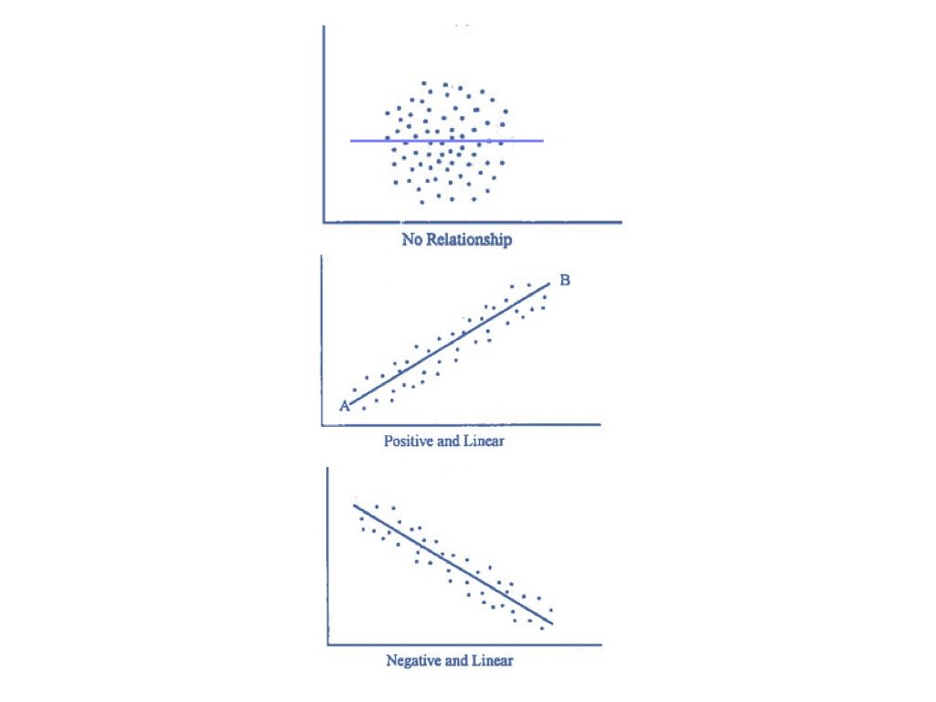

## linear model parameters

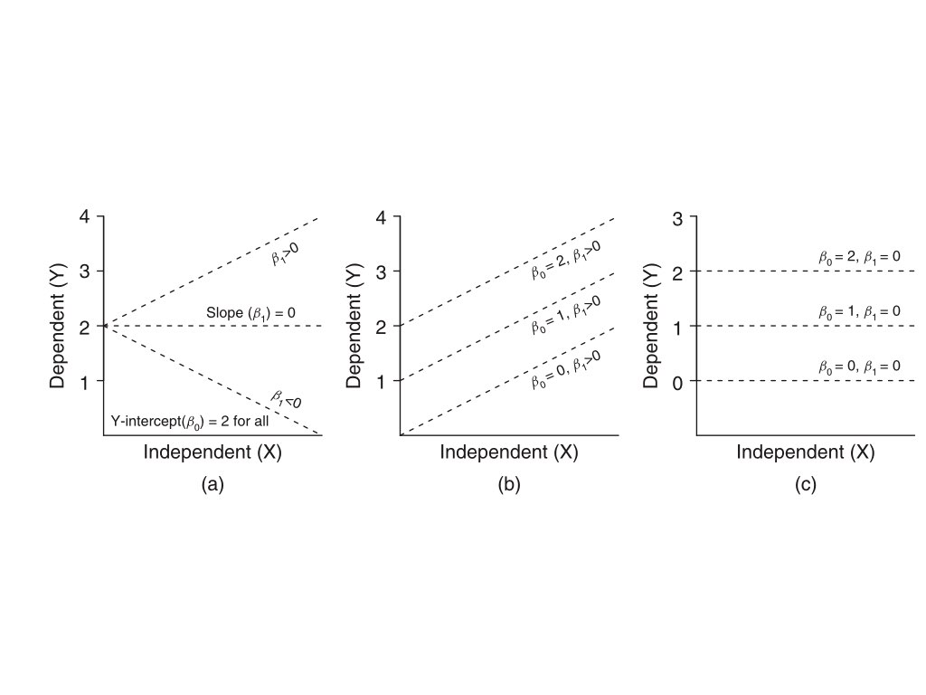

## linear models in R

All of these will *include* the intercept

```r
Y~X
Y~1+X
Y~X+1
```

```r
Y~X
Y~1+X
Y~X+1
```

Need to fit the model and then ‘read’ the output

```r
trial_lm <- lm(Y~X)
summary (trial_lm)
```

## R INTERLUDE

Write a script to read in the perchlorate data set. Now, add the code to perform a linear model of two continuous variables. Notice how the output of the linear model is specified to a new variable. Also note that the variables and dataset are placeholders

```r
my_lm <- lm(dataset$variable1 ~ dataset$variable2)
```

Now look at a summary of the linear model

```r
summary(my_lm)
print(my_lm)
```

Now let’s produce a nice regression plot

```r
plot(dataset$variable1 ~ dataset$variable2, col = “blue”)
abline(my_lm, col = “red”)
```

Notice that you are adding the fitted line from your linear model Finally, remake this plot in GGPlot2

## R INTERLUDE

- zfish_diet_IA.tsv
  - Protein - amount of protein in the diet
  - Weight - weight of the fish
  - SL - standard length of the fish
- Perchlorate_Data.tsv
  - Strain - of zebrafish
  - Perchlorate Level - treatment of perchlorate
  - T4 Hormone Level
  - Follicle Area
  - Number of Follicles
  - Age_Category
  - Testes Area
  - Testes Stage

## R INTERLUDE

```r
Perchlorate_Data <- read.table(‘perchlorate_data.tsv’, header=T, sep=‘/t’)
head(Perchlorate_Data)

x <- Perchlorate_Data$T4_Hormone_Level
y <- Perchlorate_Data$Testes_Area

perc_lm <- lm(y ~ x)
summary (perc_lm)

plot(y ~ x, col = "blue")
abline(perc_lm, col = "red")
```

## R INTERLUDE - Checking the output

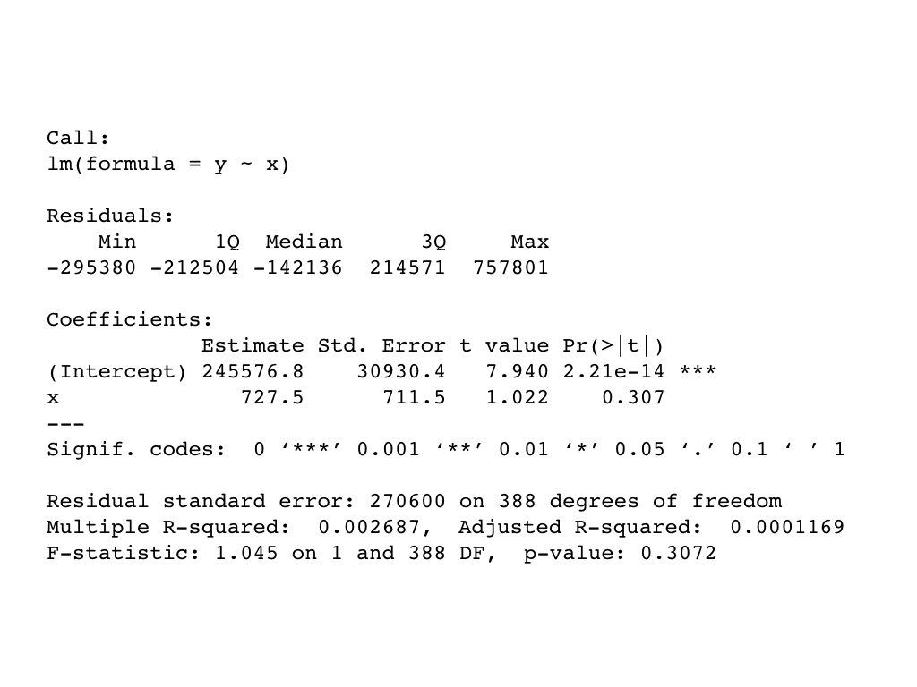

## Model fitting and hypothesis tests in regression

\[H_0 : \beta_0 = 0\] \[H_0 : \beta_1 = 0\]

full model - \(y_i = \beta_0 + \beta_1*x_i + error_i\)

reduced model - \(y_i = \beta_0 + 0*x_i + error_i\)

1. fits a “reduced” model without slope term (H0)
2. fits the “full” model with slope term added back
3. compares fit of full and reduced models using an F test

## Model fitting and hypothesis tests in regression

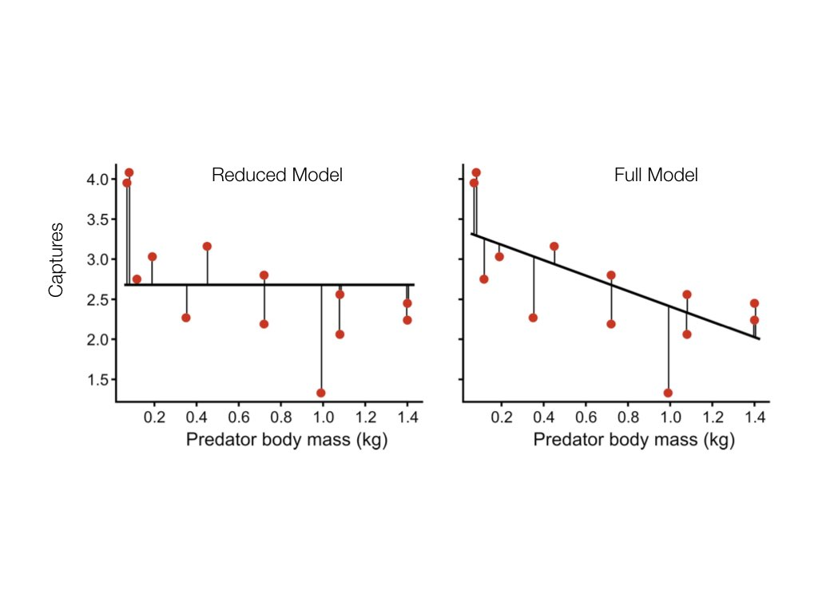

## Hypothesis tests in linear regression

Estimation of the variation that is explained by the model (SS_model)

SS_model = SS_total(reduced model) - SS_residual(full model)

The variation that is unexplained by the model (SS_residual)

SS_residual(full model)

## Hypothesis tests in linear regression

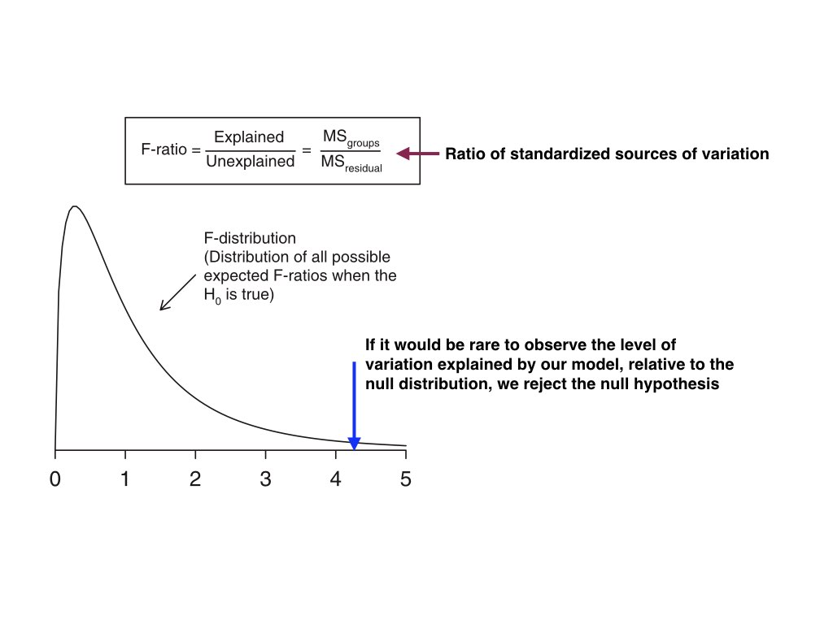

## Hypothesis tests in linear regression

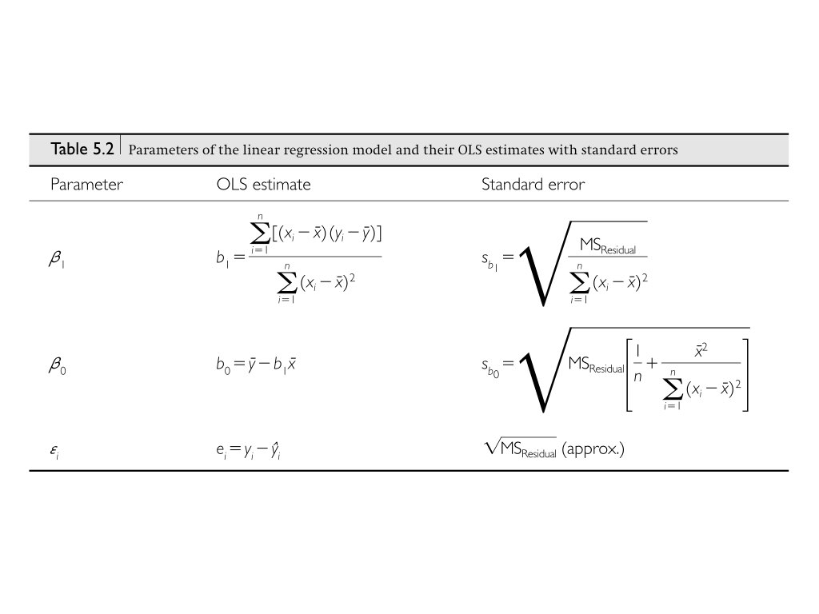

## \(r^2\) as a measure of model fit

\[r^2 = SS_{regression}/SS_{total} = 1 - (SS_{residual}/SS_{total})\] or \[r^2 = 1 - (SS_{residual(full)}/SS_{total(reduced)})\] Which is the proportion of the variance in Y that is explained by X

## Relationship of correlation and regression

\[\beta_{YX}=\rho_{YX}*\sigma_Y/\sigma_X\] \[b_{YX} = r_{YX}*S_Y/S_X\]

## Residual Analysis

### did we meet our assumptions?

- Independent errors (residuals)
- Equal variance of residuals in all groups
- Normally-distributed residuals
- Robustness to departures from these assumptions is improved when sample size is large and design is balanced

## Residual Analysis

### did we meet our assumptions?

\[y_i = \beta_0 + \beta_1 * x_I + \epsilon_i\]

## Residual Analysis

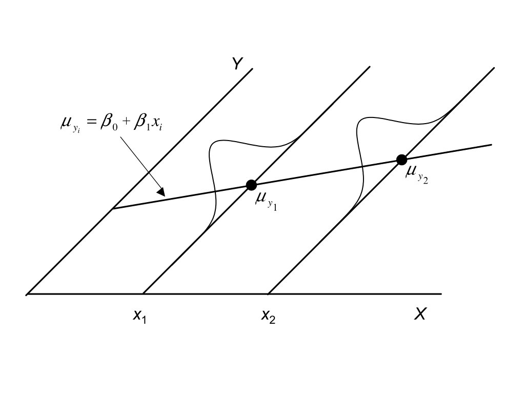

## Residual Analysis

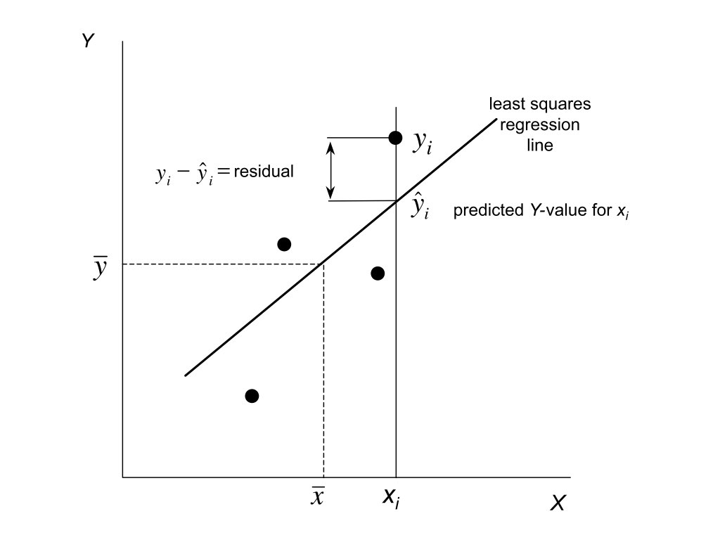

## Handling violations of the assumptions of linear models

- What if your residuals aren’t normal because of outliers?
- Nonparametric methods exist, but these don’t provide parameter estimates with CIs.
- Robust regression (rlm)
- Randomization tests

## Anscombe’s quartet again

### what would residual plots look like for these?

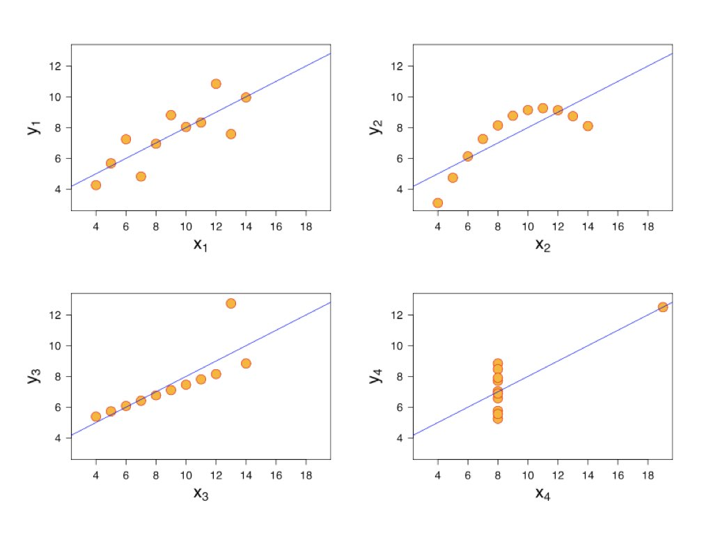

## Anscombe’s quartet again

### what would residual plots look like for these?

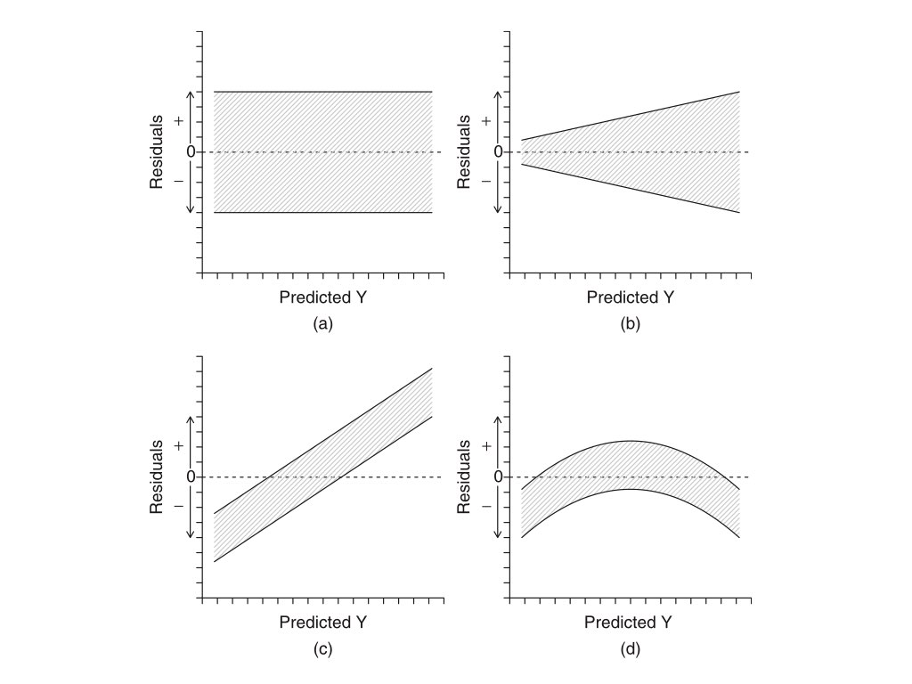

## Residual Plots

### Spotting assumption violations

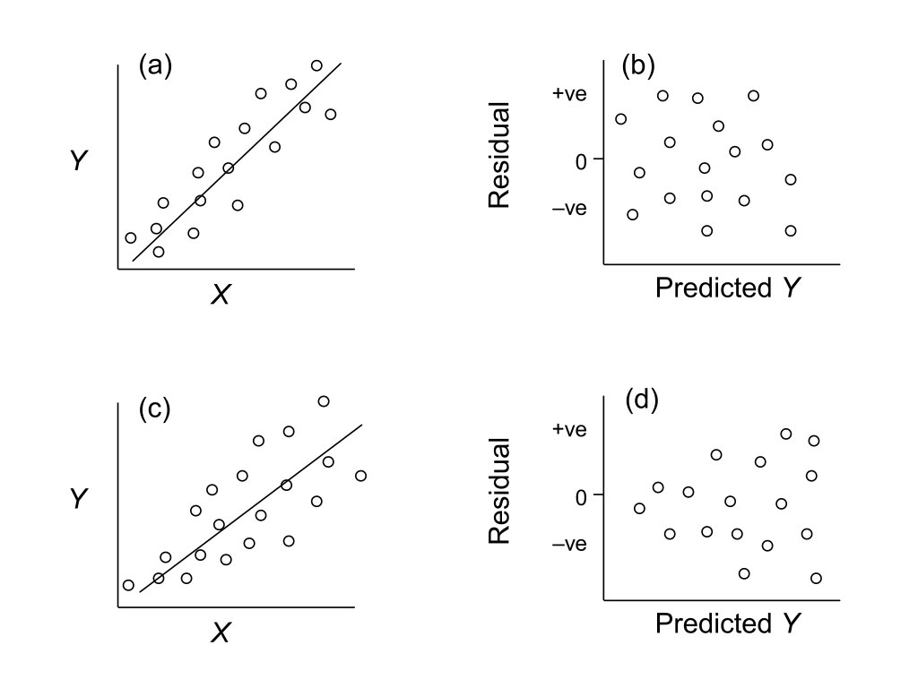

## Residuals

### leverage and influence

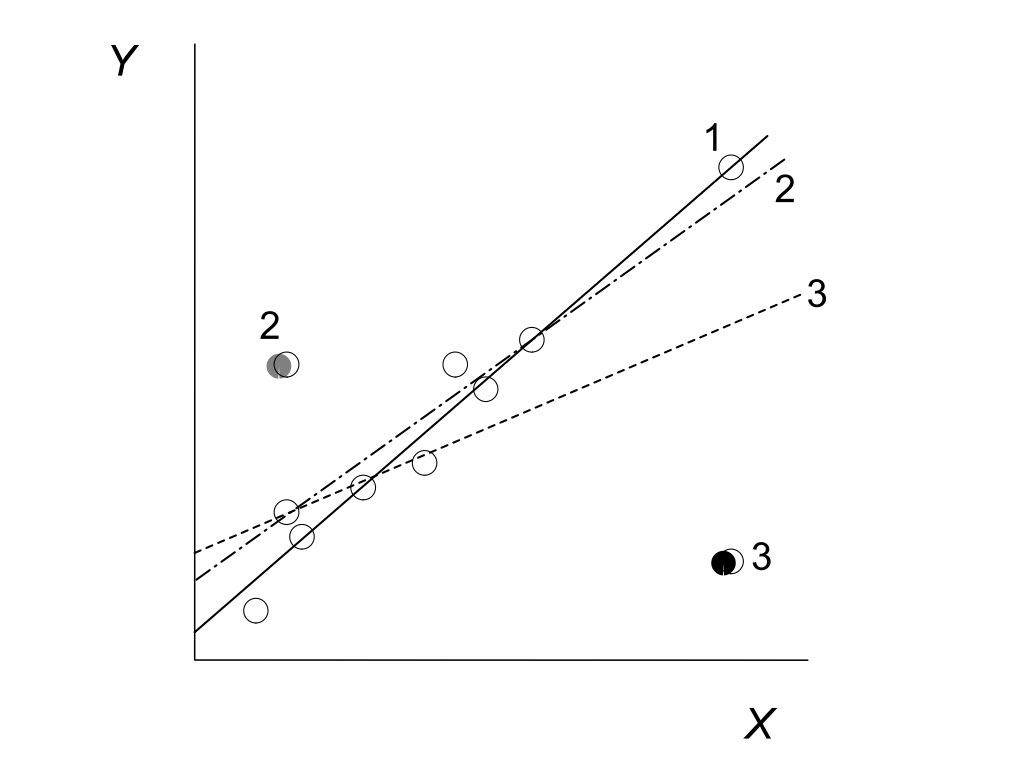

## Residuals

### leverage and influence

- **Leverage** - a measure of how much of an outlier each point is in x-space (on x-axis) and thus only applies to the predictor variable. (Values > 2*(2/n) for simple regression are cause for concern)
- **Residuals** - As the residuals are the differences between the observed and predicted values along a vertical plane, they provide a measure of how much of an outlier each point is in y-space (on y-axis). The patterns of residuals against predicted y values (residual plot) are also useful diagnostic tools for investigating linearity and homogeneity of variance assumptions
- **Cook’s D** statistic is a measure of the influence of each point on the fitted model (estimated slope) and incorporates both leverage and residuals. Values ≥ 1 (or even approaching 1) correspond to highly influential observations.

## R INTERLUDE

### residual analyses

Let’s look at the zebrafish diet data.

```r
x <- zfish_diet$Protein
y <- zfish_diet$Weight

zfish_lm <- lm(y ~ x)
summary (zfish_lm)

plot(y ~ x, col = "blue")
abline(zfish_lm, col = "red")

hist(residuals(zfish_lm), breaks=30)

plot (residuals(zfish_lm) ~ fitted.values(zfish_lm))
plot (residuals(zfish_lm) ~ x)
```

## R INTERLUDE

### residual analyses

Or apply the plot() function to the linear model object directly

```r
plot(zfish_lm)
```

Figure out what these plots are telling you

## R INTERLUDE

How about using the influence.measures function???

```r
influence.measures(zfish_lm)
```

Do we have any high leverage observations we need to worry about??? Now go back and try to recreate these graphs in GGPlot2